# R Notebook

# 1 Introduction (including choice of data, questions), Team description

# 2 Description of Data

We get the dataset from the Global Terrorism Database (GTD) http://start.umd.edu/gtd/, which is an open-source database including information on terrorist events around the world from 1970 through 2016 (with annual updates planned for the future). Unlike many other event databases, the GTD includes systematic data on domestic as well as international terrorist incidents that have occurred during this time period and now includes more than 170,000 cases. The dataset ends in 2016 because GTD collection beyond 2016 is ongoing and the website is updated annually. They expect to release the 2017 data in Summer 2018.

```r
library(openxlsx)
library(dplyr)
```

```r
library(ggplot2)
library(ggthemes)
library(rworldmap)
library(tidyverse)
```

# 3 Graphical Analysis of Data Quality

```r
terrorism <- read.xlsx("../data/raw data/globalterrorismdb_0617dist.xlsx")
terrorism1<-terrorism[terrorism$iyear<=1974,]
#write.csv(terrorism1,"terrorism1.csv")
terrorism2<-terrorism[terrorism$iyear>=2012,]
#write.csv(terrorism2,"terrorism2.csv")
```

## 3.1 discover what’s in the data file that was exported

```r
## choose variables
```

# 4 Main Analysis (focus on quality of EDA choices / techniques)

## 4.4 Terrorist Attack Targets in 1970 and 2016

There are a lot of different terrorist attack targets in our dataset, such as Government, Military, Education Institutions and so on. We would like to compare the top 10 terrorist attack targets in the first 1970 and the last year 2016 in our dataset. The variation in terrorist attack targets may be related to the policy issues, motivations and religions, etc.

```r
library(gridExtra)
```

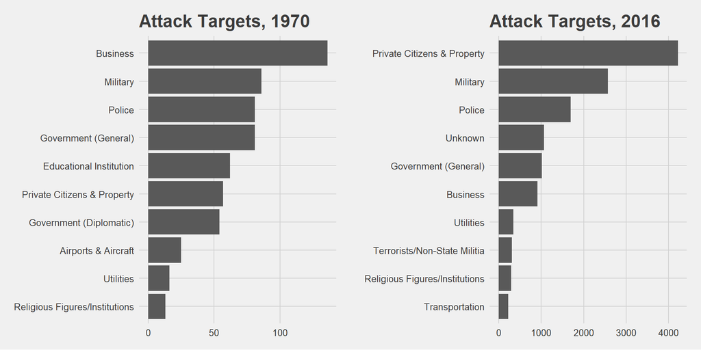

```r
attack1970 <- terrorism[terrorism$iyear==1970, ]
by_target <- attack1970 %>% group_by(targtype1_txt) %>%
  summarise(n=n())
by_target <- arrange(by_target, desc(n))%>% head(10)

p1<-ggplot(aes(x=reorder(targtype1_txt, n), y=n), data=by_target) +
  geom_bar(stat = 'identity') + ggtitle('Attack Targets, 1970') +
  coord_flip() + theme_fivethirtyeight()

attack2016 <- terrorism[terrorism$iyear==2016, ]
by_target <- attack2016 %>% group_by(targtype1_txt) %>%
  summarise(n=n())
by_target <- arrange(by_target, desc(n))%>% head(10)

p2<-ggplot(aes(x=reorder(targtype1_txt, n), y=n), data=by_target) +
  geom_bar(stat = 'identity') + ggtitle('Attack Targets, 2016') +
  coord_flip() + theme_fivethirtyeight()

grid.arrange(p1, p2, nrow = 1)
```

For the top 10 terrorist attack targets, they require the most homeland security resources. Policymakers can use these and other results to focus their counter-terrorism measures.

## 4.5 A heatmap of total number of terrorist attacks worldwide

To compare the total number of terrorist attacks worldwide, we draw the following two heatmaps.

```r
#install.packages('rworldmap')
#library(rworldmap)
a <- rle(sort(terrorism1$country_txt))
b <- data.frame(country_txt=a$values, number_of_torrorism_attacks_from_1970_to_1974 = a$lengths)

gtdMap <- joinCountryData2Map( b,
                               nameJoinColumn="country_txt",
                               joinCode="NAME" )
```

```
## 67 codes from your data successfully matched countries in the map
## 9 codes from your data failed to match with a country code in the map
## 176 codes from the map weren't represented in your data
```

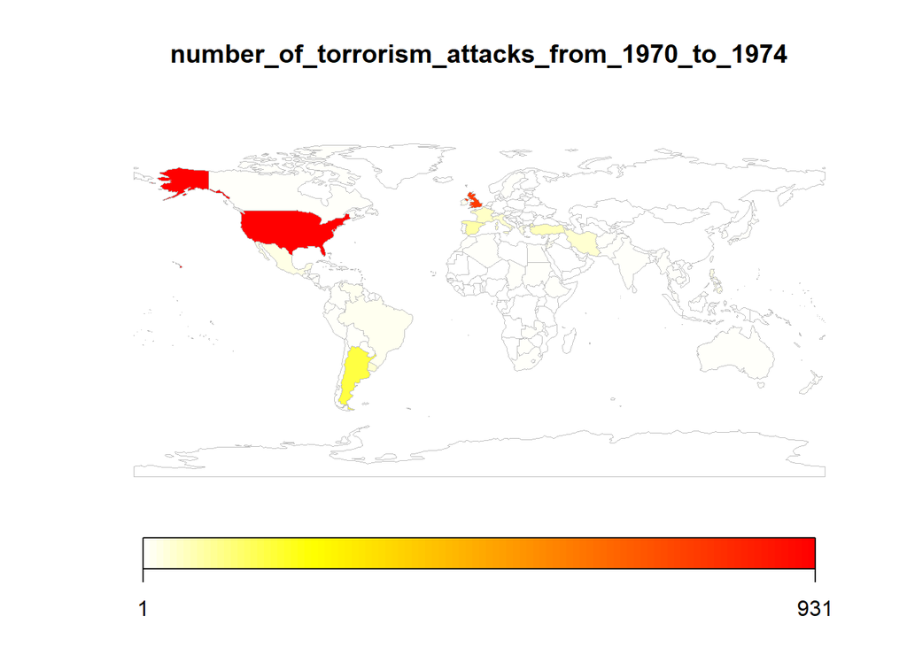

```r
#mapDevice('x11')
mapCountryData( gtdMap,
                nameColumnToPlot='number_of_torrorism_attacks_from_1970_to_1974',
                catMethod='fixedWidth',
                numCats=100 )
```

```r
a <- rle(sort(terrorism2$country_txt))
b <- data.frame(country_txt=a$values, number_of_torrorism_attacks_from_2012_to_2016 = a$lengths)

gtdMap <- joinCountryData2Map( b,
                               nameJoinColumn="country_txt",
                               joinCode="NAME" )
```

```
## 137 codes from your data successfully matched countries in the map
## 1 codes from your data failed to match with a country code in the map
## 106 codes from the map weren't represented in your data
```

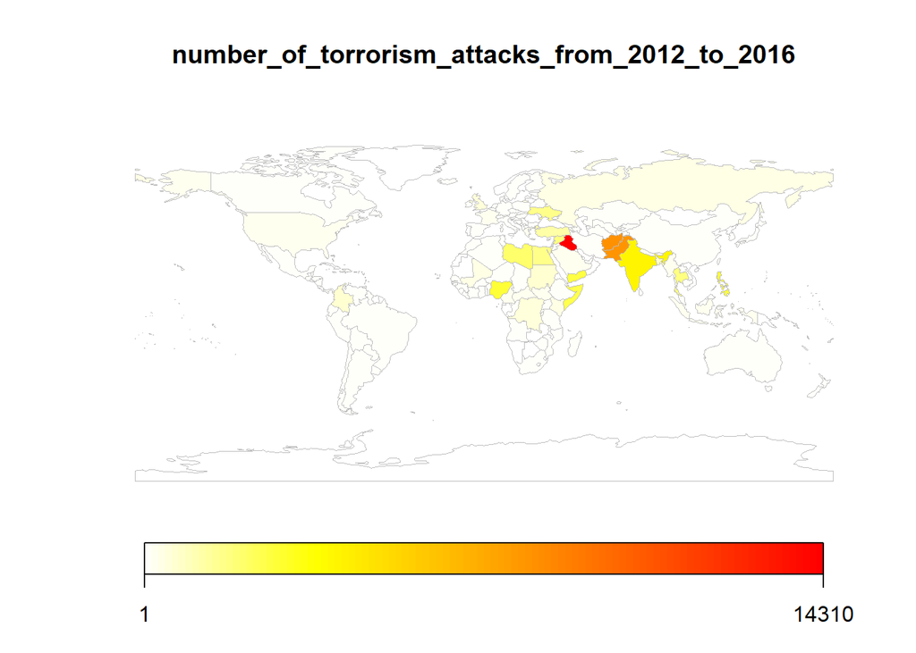

```r
#mapDevice('x11')
mapCountryData( gtdMap,
                nameColumnToPlot='number_of_torrorism_attacks_from_2012_to_2016',
                catMethod='fixedWidth',
                numCats=100 )
```

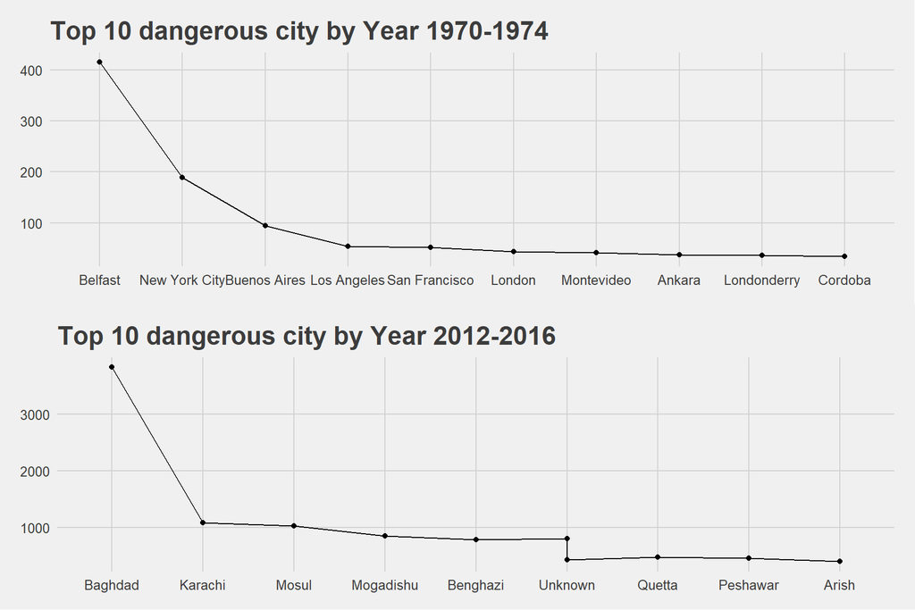

```r
attack_by_city <- terrorism1 %>% group_by(country_txt, city) %>%
  summarise(n=n())
attack_by_city <- arrange(attack_by_city, desc(n))
top10_city<- head(attack_by_city, 10)

p1<-ggplot(data=top10_city, aes(x=reorder(city,-n), y=n, group=1)) +
  geom_line()+
  geom_point() + xlab("City") + ylab("Number of terrorist Attacks") +
        ggtitle("Top 10 dangerous city by Year 1970-1974") + theme_fivethirtyeight()

attack_by_city <- terrorism2 %>% group_by(country_txt, city) %>%
  summarise(n=n())
attack_by_city <- arrange(attack_by_city, desc(n))
top10_city<- head(attack_by_city, 10)

p2<-ggplot(data=top10_city, aes(x=reorder(city,-n), y=n, group=1)) +
  geom_line()+
  geom_point() + xlab("City") + ylab("Number of terrorist Attacks") +
        ggtitle("Top 10 dangerous city by Year 2012-2016") + theme_fivethirtyeight()
grid.arrange(p1, p2, nrow = 2)
```

The most dangeours cities are very different in these two periods. During 1970-1974, the most dangerous cities are in United Kingdom, United States, Argentina, Uruguay and Turkey. Belfast was the most dangerous city in 1970-1974, with approximately 400 terrorist attacks in all.

## 4.7 Terrorist Attacks distribution by Region and Year 1970-1974 & 2012-2016

We also feel curious about the distribution worldwide by region in each year of both of the time ranges,‘1970-1974’and’2012-2016’. On the basis of this series of barcharts, we can know more about the questions like: ‘if the terrorist attack distribution of each year inside each time range is similar with each other?’ or ‘if there is any major differences between the 2 time ranges in terrorrist attacks distribution by region?’ To solve these problems, we built up the barcharts below.

```r
terrorism1970 <- read.csv('../data/terrorism1.csv', stringsAsFactors = F)
terrorism2012 <- read.csv('../data/terrorism2.csv', stringsAsFactors = F)
```

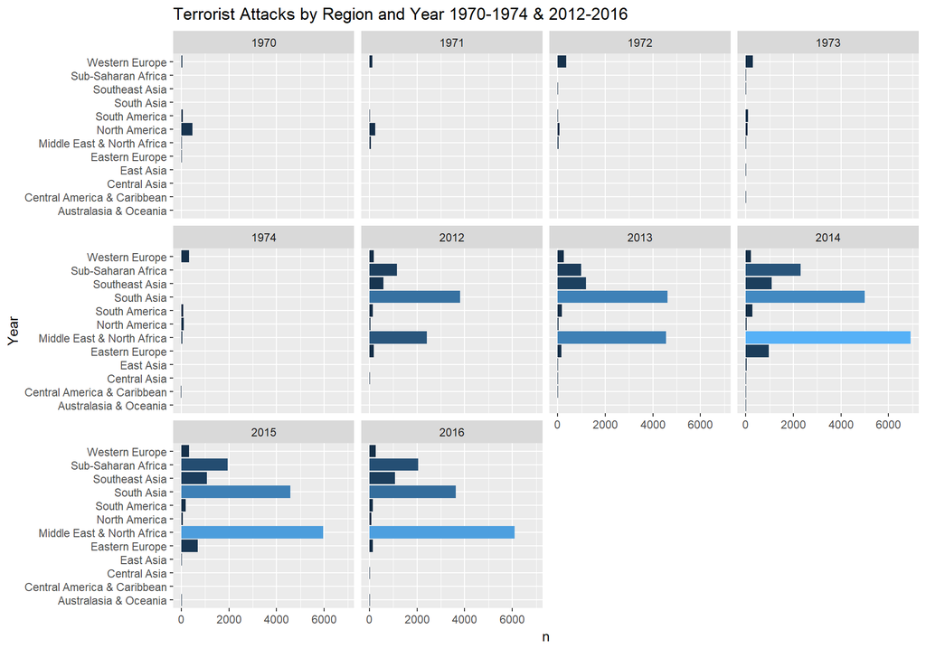

```r
#library(tidyverse)
combine <- subset(terrorism, iyear<=1974 | iyear>=2012)
by_year <- combine %>% group_by(iyear,region_txt) %>%
  summarise(n=n())
ggplot(by_year, aes(x = region_txt, y = n, fill = n)) +
  geom_bar(stat = 'identity') +
  facet_wrap(~iyear) + xlab('Year') + coord_flip() +
  ggtitle('Terrorist Attacks by Region and Year 1970-1974 & 2012-2016') +
  theme(legend.position="none")
```

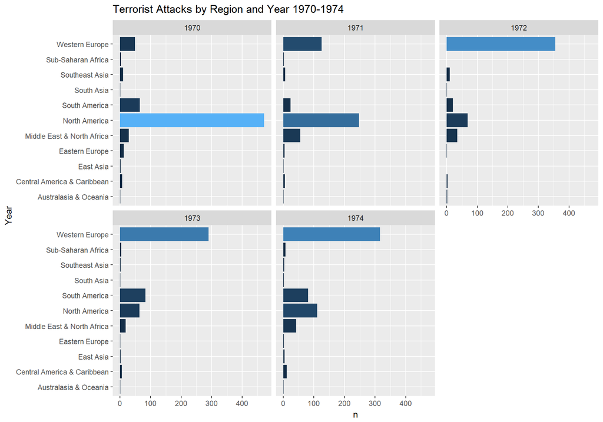

```r
by_year <- terrorism1970 %>% group_by(iyear,region_txt) %>%
  summarise(n=n())
ggplot(by_year, aes(x = region_txt, y = n, fill = n)) +
  geom_bar(stat = 'identity') +
  facet_wrap(~iyear) + xlab('Year') + coord_flip() +
  ggtitle('Terrorist Attacks by Region and Year 1970-1974') +
  theme(legend.position="none")
```

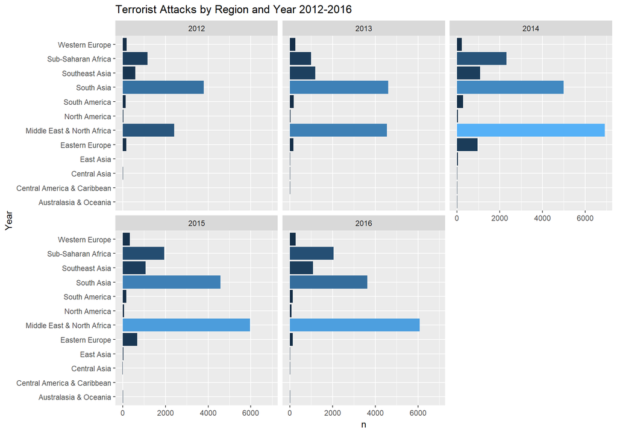

```r
by_year <- terrorism2012 %>% group_by(iyear,region_txt) %>%
  summarise(n=n())
ggplot(by_year, aes(x = region_txt, y = n, fill = n)) +
  geom_bar(stat = 'identity') +
  facet_wrap(~iyear) + xlab('Year') + coord_flip() +
  ggtitle('Terrorist Attacks by Region and Year 2012-2016') +
  theme(legend.position="none")
```

From the graphs above, we can conclude that compared with 40 years ago, the world is obviuosly more dangerous. In the era of 1970s, America and Western Europe are the most dangerous regions throughout the world, while in the ear of 2010s, Middle East, North Africa and South Asia already became the target regions of terrorrists, which means, the patterns have been subverted completely.

Simultaneously, we plotted pie charts to compare the contribution of each region for the occurance of terrorist attacks in the world.

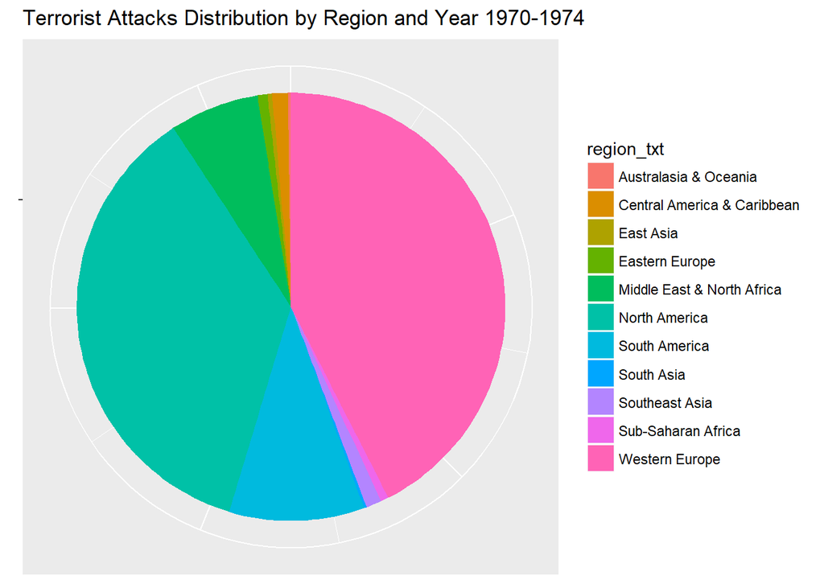

```r
NAmericadist <- terrorism1970 %>% group_by(region_txt) %>%
  summarise(n=n())

bp<- ggplot(NAmericadist, aes(x="", y=n, fill=region_txt))+
geom_bar(width = 1, stat = "identity")
pie <- bp + coord_polar("y", start=0)
pie + theme(axis.text.x=element_blank(), axis.title.x = element_blank(),
  axis.title.y = element_blank()) + ggtitle('Terrorist Attacks Distribution by Region and Year 1970-1974')
```

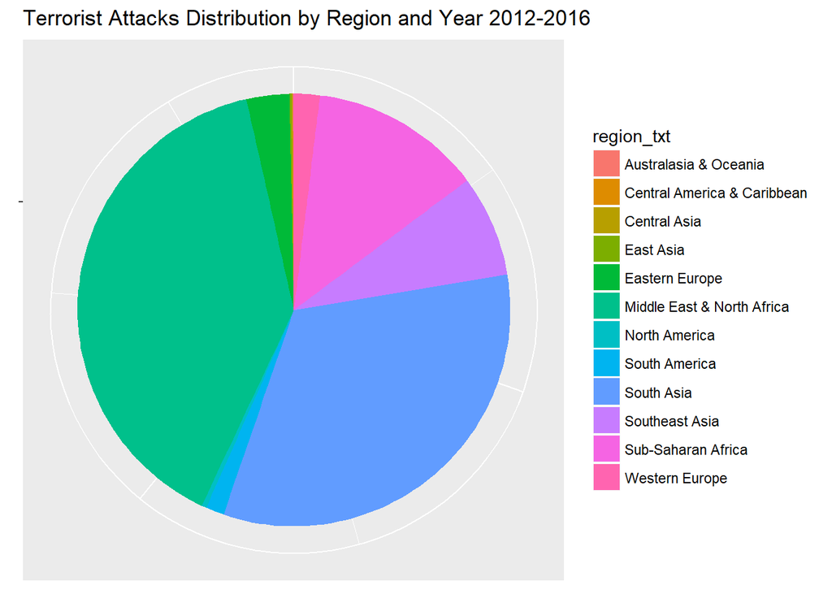

```r
MENAdist <- terrorism2012 %>% group_by(region_txt) %>%
  summarise(n=n())
bp<- ggplot(MENAdist, aes(x="", y=n, fill=region_txt))+
geom_bar(width = 1, stat = "identity")
pie <- bp + coord_polar("y", start=0)
pie + theme(axis.text.x=element_blank(), axis.title.x = element_blank(),
  axis.title.y = element_blank()) + ggtitle('Terrorist Attacks Distribution by Region and Year 2012-2016')
```

The pie charts above show that coampared with 40 years ago, the target regions of terrorist attacks became more diverse, and the areas involved are more extensive.

## 4.8 Comparison between Terrorist Attack numbers in Middle East & North Africa and North America by Year 1970-1974

On the ground of the analysis above, we want ot pay more attention to 2 major regions full of collisions during the past years, which are Middle East & North Africa and North America. Firstly we want to compare the numbers of attacks of the 2 regions in 1970-1974.

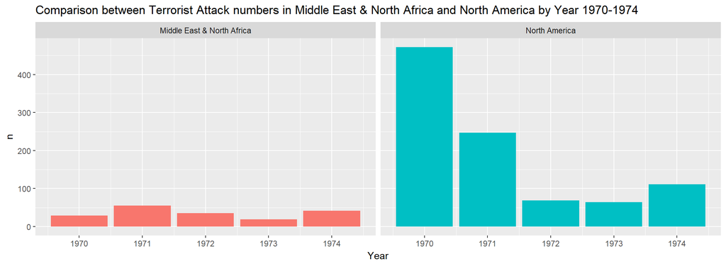

```r
NA_MENA <- subset(terrorism1970, region_txt == "North America" | region_txt == "Middle East & North Africa")
n_NAMENA <- NA_MENA %>% group_by(region_txt, iyear) %>%
  summarise(n=n())
ggplot(n_NAMENA, aes(x = iyear, y = n, fill = region_txt)) +
  geom_col() +
  xlab('Year') +
  facet_wrap(~ region_txt) +
  theme(legend.position = "none") +
ggtitle("Comparison between Terrorist Attack numbers in Middle East & North Africa and North America by Year 1970-1974")
```

And this is the comparison during the period of 2012-2016.

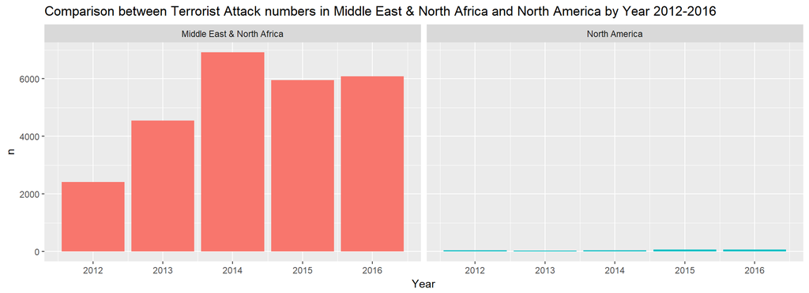

```r
NA_MENA <- subset(terrorism2012, region_txt == "North America" | region_txt == "Middle East & North Africa")
n_NAMENA <- NA_MENA %>% group_by(region_txt, iyear) %>%
  summarise(n=n())
ggplot(n_NAMENA, aes(x = iyear, y = n, fill = region_txt)) +
  geom_col() +
  xlab('Year') +
  facet_wrap(~ region_txt) +
  theme(legend.position = "none") +
ggtitle("Comparison between Terrorist Attack numbers in Middle East & North Africa and North America by Year 2012-2016")
```

The contrast is corrsponding to the conclusion we got in the last part.

## 4.9 Types of Terrorist Attacks in North America and Middle East & North Africa by Year 1970-1974

Now that we know the distribution of attack numbers among years, we want to know more details about these terrorist activities. So the barchart below will show us the contribution of different attack types in a certain year and a certain region.

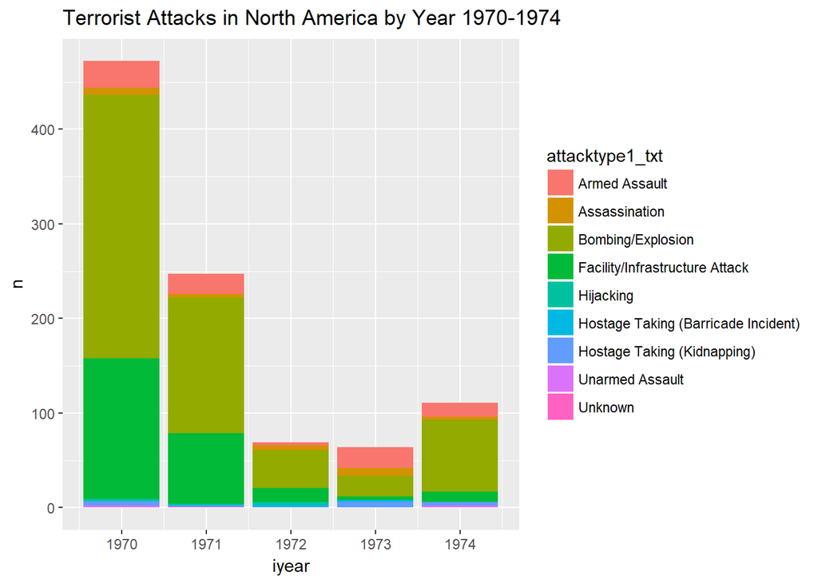

```r
#library(ggplot2)
#library(dplyr)
#install.packages('ggthemes')
#library(ggthemes)
NorthAmerica <- terrorism1970[terrorism1970$region_txt=='North America', ]
NorthAmerica_type <- NorthAmerica %>% group_by(attacktype1_txt, iyear) %>%
  summarise(n=n())
ggplot(aes(x = iyear, y = n, fill = attacktype1_txt), data = NorthAmerica_type) + geom_bar(stat = 'identity') +
ggtitle("Terrorist Attacks in North America by Year 1970-1974")
```

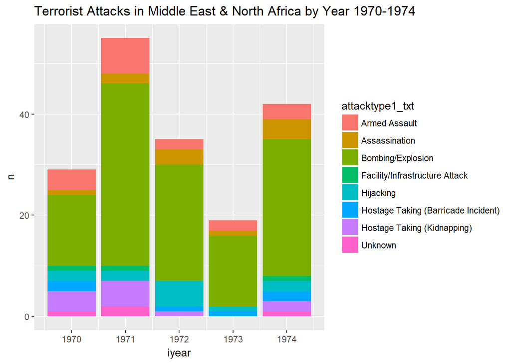

```r
MENA <- terrorism1970[terrorism1970$region_txt=='Middle East & North Africa', ]
MENA_type <- MENA %>% group_by(attacktype1_txt, iyear) %>%
  summarise(n=n())
ggplot(aes(x = iyear, y = n, fill = attacktype1_txt), data = MENA_type) + geom_bar(stat = 'identity') +
ggtitle("Terrorist Attacks in Middle East & North Africa by Year 1970-1974")
```

For North America in 1970s, explosion occupied a large proportion of all of the attack types, and there are also lots of infrastructure attacks. On the other hand, for Middle East & North Africa in 1970s, explosion is also a major type of attacks, but other main methods of attacks are armed assault, kidnapping and Hijacking,

## 4.10 Types of Terrorist Attacks in North America and Middle East & North Africa by Year 2012-2016

[figure not shown]

```r
NorthAmerica <- terrorism2012[terrorism2012$region_txt=='North America', ]
NorthAmerica_type <- NorthAmerica %>% group_by(attacktype1_txt, iyear) %>%
  summarise(n=n())
ggplot(aes(x = iyear, y = n, fill = attacktype1_txt), data = NorthAmerica_type) + geom_bar(stat = 'identity') +
ggtitle("Terrorist Attacks in North America by Year 1970-1974")
```

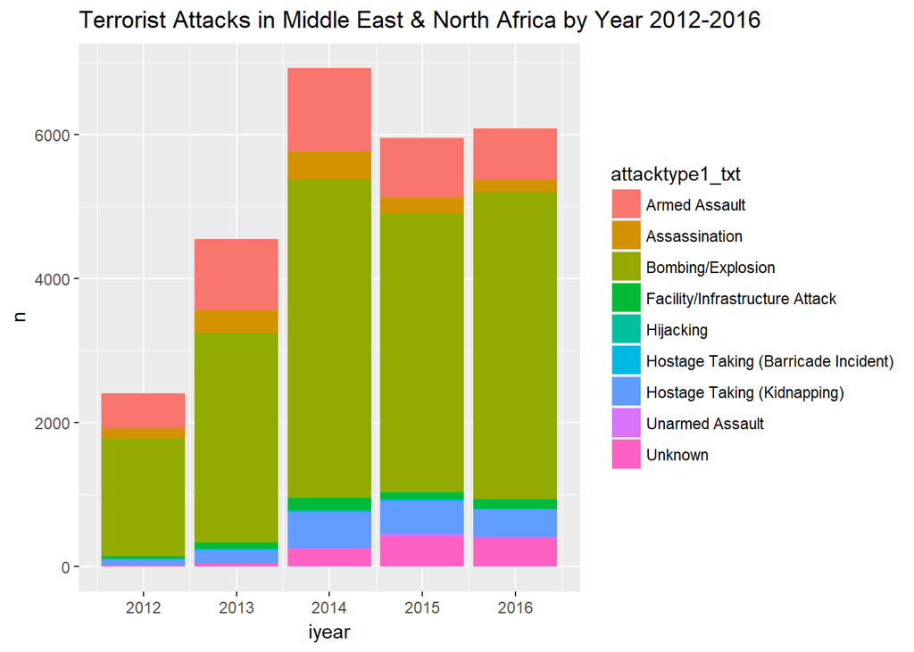

```r
MENA <- terrorism2012[terrorism2012$region_txt=='Middle East & North Africa', ]
MENA_type <- MENA %>% group_by(attacktype1_txt, iyear) %>%
  summarise(n=n())
ggplot(aes(x = iyear, y = n, fill = attacktype1_txt), data = MENA_type) + geom_bar(stat = 'identity') +
ggtitle("Terrorist Attacks in Middle East & North Africa by Year 2012-2016")
```

In comparison with 40 years ago, for North America, the percentage of explosion decreased, but infrastructure attack became the most major attack type. However, for Middle East & North Africa, the distribution has not changed a lot, and the quantity of explosion is overwelmingly large.

## 4.11 Comparison of Terrorist Attacks Distribution by Country in North America& Middle East & North Africa and Year 1970-1974&2012-2016

At present, we combine the 2 regions together to explore the contribution of each country in the 2 regions.

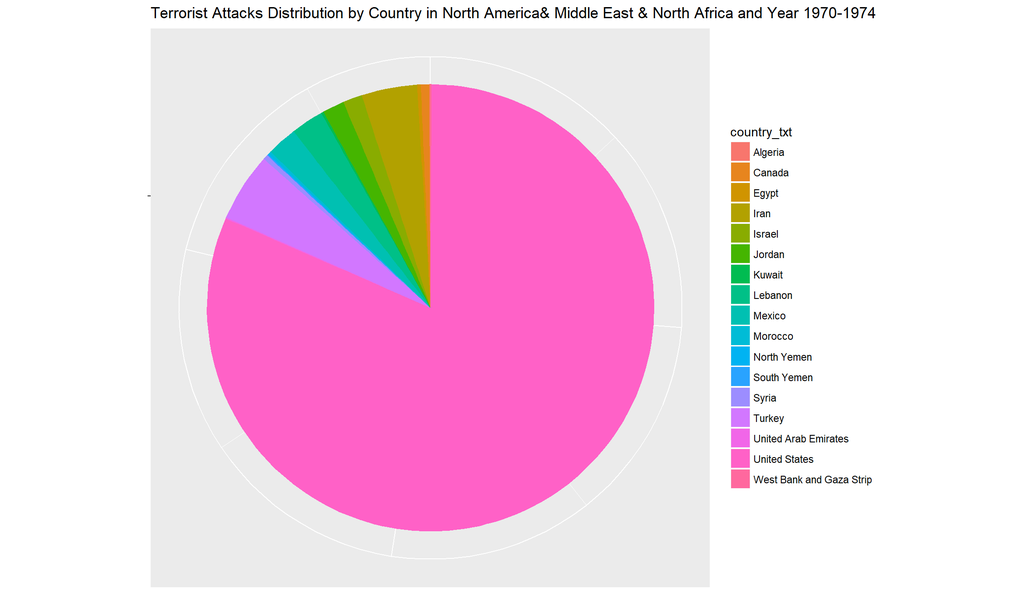

```r
NA_MENA <- subset(terrorism1970, region_txt == "North America" | region_txt == "Middle East & North Africa")
n_NAMENA <- NA_MENA %>% group_by(country_txt) %>%
  summarise(n=n())
bp<- ggplot(n_NAMENA, aes(x="", y=n, fill=country_txt))+
geom_bar(width = 1, stat = "identity")
pie <- bp + coord_polar("y", start=0)
pie + theme(axis.text.x=element_blank(), axis.title.x = element_blank(),
  axis.title.y = element_blank()) + ggtitle('Terrorist Attacks Distribution by Country in North America& Middle East & North Africa and Year 1970-1974')
```

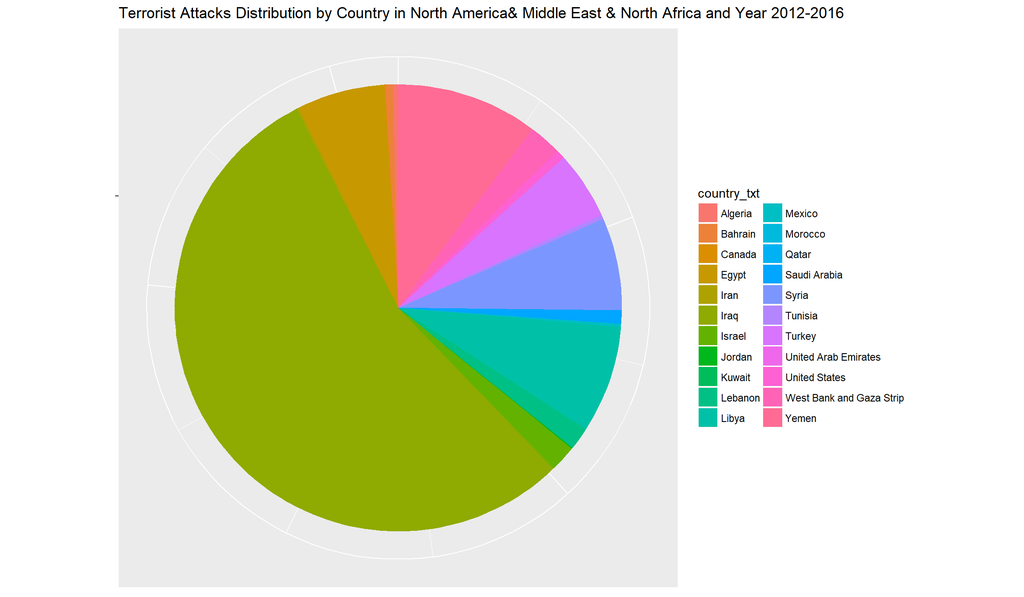

```r
NA_MENA <- subset(terrorism2012, region_txt == "North America" | region_txt == "Middle East & North Africa")
n_NAMENA <- NA_MENA %>% group_by(country_txt) %>%
  summarise(n=n())
bp<- ggplot(n_NAMENA, aes(x="", y=n, fill=country_txt))+
geom_bar(width = 1, stat = "identity")
pie <- bp + coord_polar("y", start=0)
pie + theme(axis.text.x=element_blank(), axis.title.x = element_blank(),
  axis.title.y = element_blank()) + ggtitle('Terrorist Attacks Distribution by Country in North America& Middle East & North Africa and Year 2012-2016')
```

It is self-evident that Iraq replaced the status of America to become the most dangerous country amoung North America& Middle East & North Africa. This probabily because of the influence of the Iraq war, and we can induce that most of risks are transferred to Middle East from United States.

## 4.12 Comparison of Terrorist Attacks Distribution by Country in North America and Year 1970-1974 & 2012-2016

On the basis of this, we want to concentrate on the 2 regions separately and analyse the relative safety of countries in some region.

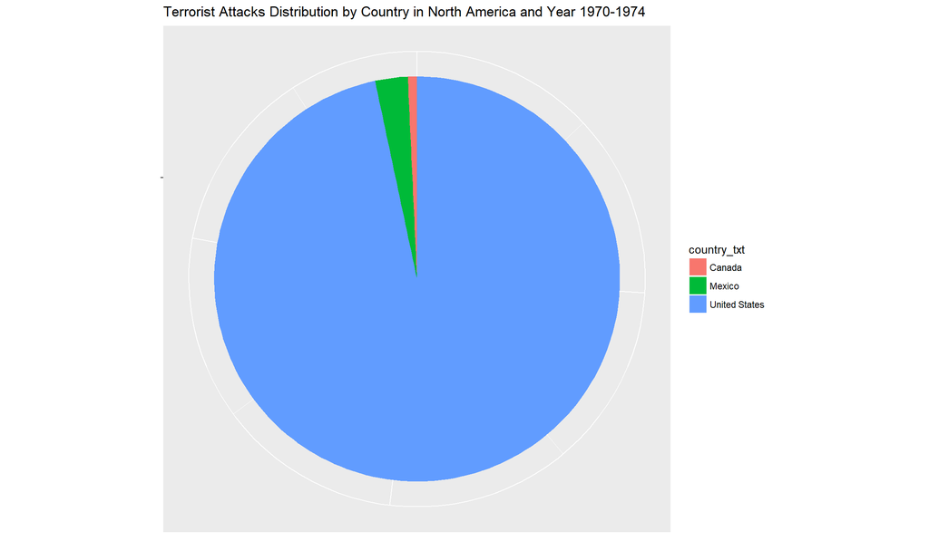

```r
NAmerica <- subset(terrorism1970, region_txt == "North America")
n_NA <- NAmerica %>% group_by(country_txt) %>%
  summarise(n=n())
bp<- ggplot(n_NA, aes(x="", y=n, fill=country_txt))+
geom_bar(width = 1, stat = "identity")
pie <- bp + coord_polar("y", start=0)
pie + theme(axis.text.x=element_blank(), axis.title.x = element_blank(),
  axis.title.y = element_blank()) + ggtitle('Terrorist Attacks Distribution by Country in North America and Year 1970-1974')
```

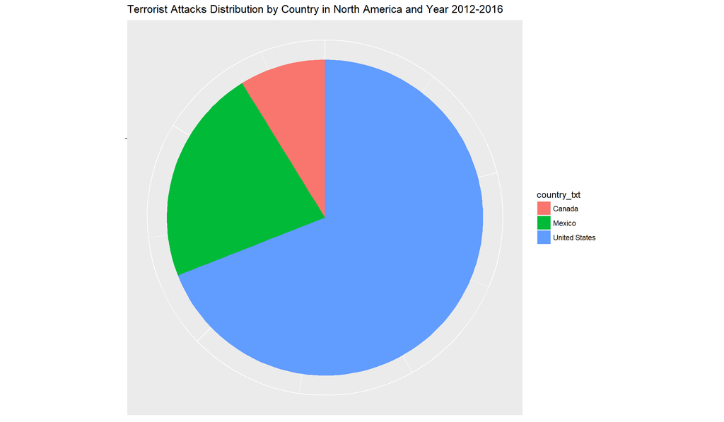

```r
NAmerica <- subset(terrorism2012, region_txt == "North America")
n_NA <- NAmerica %>% group_by(country_txt) %>%
  summarise(n=n())
bp<- ggplot(n_NA, aes(x="", y=n, fill=country_txt))+
geom_bar(width = 1, stat = "identity")
pie <- bp + coord_polar("y", start=0)
pie + theme(axis.text.x=element_blank(), axis.title.x = element_blank(),
  axis.title.y = element_blank()) + ggtitle('Terrorist Attacks Distribution by Country in North America and Year 2012-2016')
```

According to the pie charts, we found that although United States is still the most major attack target in North America, but the risks of Mexico and Canada increased evidently compared with 40 years ago. But all in all, Canada is still the safest country in North America.